$$ \newcommand{\esp}[1]{\mathbb{E}\left(#1\right)} \newcommand{\var}[1]{\mbox{Var}\left(#1\right)} \newcommand{\deriv}[1]{\dot{#1}(t)} \newcommand{\prob}[1]{ \mathbb{P}\!(#1)} \newcommand{\eqdef}{\mathop{=}\limits^{\mathrm{def}}} \newcommand{\by}{\boldsymbol{y}} \newcommand{\bc}{\boldsymbol{c}} \newcommand{\bpsi}{\boldsymbol{\psi}} \def\pmacro{\texttt{p}} \def\like{{\cal L}} \def\llike{{\cal LL}} \def\logit{{\rm logit}} \def\probit{{\rm probit}} \def\one{{\rm 1\!I}} \def\iid{\mathop{\sim}_{\rm i.i.d.}} \def\simh0{\mathop{\sim}_{H_0}} \def\df{\texttt{df}} \def\res{e} \def\xomega{x} \newcommand{\argmin}[1]{{\rm arg}\min_{#1}} \newcommand{\argmax}[1]{{\rm arg}\max_{#1}} \newcommand{\Rset}{\mbox{$\mathbb{R}$}} \def\param{\theta} \def\setparam{\Theta} \def\xnew{x_{\rm new}} \def\fnew{f_{\rm new}} \def\ynew{y_{\rm new}} \def\nnew{n_{\rm new}} \def\enew{e_{\rm new}} \def\Xnew{X_{\rm new}} \def\hfnew{\widehat{\fnew}} \def\degree{m} \def\nbeta{d} \newcommand{\limite}[1]{\mathop{\longrightarrow}\limits_{#1}} \def\ka{k{\scriptstyle a}} \def\ska{k{\scriptscriptstyle a}} \def\kel{k{\scriptstyle e}} \def\skel{k{\scriptscriptstyle e}} \def\cl{C{\small l}} \def\Tlag{T\hspace{-0.1em}{\scriptstyle lag}} \def\sTlag{T\hspace{-0.07em}{\scriptscriptstyle lag}} \def\Tk{T\hspace{-0.1em}{\scriptstyle k0}} \def\sTk{T\hspace{-0.07em}{\scriptscriptstyle k0}} \def\thalf{t{\scriptstyle 1/2}} \newcommand{\Dphi}[1]{\partial_\pphi #1} \def\asigma{a} \def\pphi{\psi} \newcommand{\stheta}{{\theta^\star}} \newcommand{\htheta}{{\widehat{\theta}}} $$

# Statistical tests: exercices

# 1 Gene expression

The dataset geHT.csv consists of gene expression measurements for ten genes under control and treatment conditions, with four replicates each.

1. Test the hypothesis that the mean of the control expression values is 2000.

```r
geHTdata <- read.csv("data/geHT.csv")
control <- c(geHTdata$c1,geHTdata$c2,geHTdata$c3,geHTdata$c4)
t.test(control, mu=2000)
```

```
##
##  One Sample t-test
##
## data:  control
## t = -2.174, df = 39, p-value = 0.03583
## alternative hypothesis: true mean is not equal to 2000
## 95 percent confidence interval:
##  1715.028 1989.722
## sample estimates:
## mean of x
##  1852.375
```

2. Test that there is no difference overall between the treatments and controls for any of the genes (test that the whole experiment didn’t work or there are no differentially expressed genes)

```r
treatment <- c(geHTdata$t1,geHTdata$t2,geHTdata$t3,geHTdata$t4)
t.test(control, treatment)
```

```
##
##  Welch Two Sample t-test
##
## data:  control and treatment
## t = -3.6163, df = 70.732, p-value = 0.0005564
## alternative hypothesis: true difference in means is not equal to 0
## 95 percent confidence interval:
##  -653.6098 -188.9902
## sample estimates:
## mean of x mean of y
##  1852.375  2273.675
```

```r
d <- treatment - control
t.test(d, mu=0)
```

```
##
##  One Sample t-test
##
## data:  d
## t = 6.3945, df = 39, p-value = 1.468e-07
## alternative hypothesis: true mean is not equal to 0
## 95 percent confidence interval:
##  288.0346 554.5654
## sample estimates:
## mean of x
##     421.3
```

```r
t.test(treatment, control, paired = TRUE)
```

```
##
##  Paired t-test
##
## data:  treatment and control
## t = 6.3945, df = 39, p-value = 1.468e-07
## alternative hypothesis: true difference in means is not equal to 0
## 95 percent confidence interval:
##  288.0346 554.5654
## sample estimates:
## mean of the differences
##                   421.3
```

```r
wilcox.test(treatment, control, paired = TRUE)
```

```
##
##  Wilcoxon signed rank test with continuity correction
##
## data:  treatment and control
## V = 751, p-value = 4.72e-06
## alternative hypothesis: true location shift is not equal to 0
```

3. Test if the variances for the gene expression are the same under treatment or control conditions

```r
var.test(treatment, control)
```

```
##
##  F test to compare two variances
##
## data:  treatment and control
## F = 1.9435, num df = 39, denom df = 39, p-value = 0.04102
## alternative hypothesis: true ratio of variances is not equal to 1
## 95 percent confidence interval:
##  1.027937 3.674688
## sample estimates:
## ratio of variances
##            1.94354
```

# 2 Smoking, no smoking

1. There are 88 smokers among a group of 300 people of a same population. Test that the proportion of smokers in this population is less than or equal to 0.25, greater than or equal to 0.25, equal to 0.25. Show that we can use an exact test, or a test relying on an approximation.

```r
binom.test(88, 300, 0.25, alternative = "greater")
```

```
##
##  Exact binomial test
##
## data:  88 and 300
## number of successes = 88, number of trials = 300, p-value =
## 0.04959
## alternative hypothesis: true probability of success is greater than 0.25
## 95 percent confidence interval:
##  0.2500969 1.0000000
## sample estimates:
## probability of success
##              0.2933333
```

```r
binom.test(88, 300, 0.25, alternative = "less")
```

```
##
##  Exact binomial test
##
## data:  88 and 300
## number of successes = 88, number of trials = 300, p-value = 0.9623
## alternative hypothesis: true probability of success is less than 0.25
## 95 percent confidence interval:
##  0.0000000 0.3396444
## sample estimates:
## probability of success
##              0.2933333
```

```r
binom.test(88, 300, 0.25, alternative = "two.sided")
```

```
##
##  Exact binomial test
##
## data:  88 and 300
## number of successes = 88, number of trials = 300, p-value =
## 0.08338
## alternative hypothesis: true probability of success is not equal to 0.25
## 95 percent confidence interval:
##  0.2424150 0.3483872
## sample estimates:
## probability of success
##              0.2933333
```

```r
prop.test(88, 300, 0.25, alternative = "two.sided", correct=FALSE)
```

```
##
##  1-sample proportions test without continuity correction
##
## data:  88 out of 300, null probability 0.25
## X-squared = 3.0044, df = 1, p-value = 0.08304
## alternative hypothesis: true p is not equal to 0.25
## 95 percent confidence interval:
##  0.2446863 0.3472061
## sample estimates:
##         p
## 0.2933333
```

```r
prop.test(88, 300, 0.25, alternative = "greater", correct=FALSE)
```

```
##
##  1-sample proportions test without continuity correction
##
## data:  88 out of 300, null probability 0.25
## X-squared = 3.0044, df = 1, p-value = 0.04152
## alternative hypothesis: true p is greater than 0.25
## 95 percent confidence interval:
##  0.2520976 1.0000000
## sample estimates:
##         p
## 0.2933333
```

2. There are 90 smokers in another group of 400 people, coming from another population. Can we conclude that the proportion of smokers are different in these two populations?

```r
count <- matrix(c(88, 90, 212, 310), nrow=2)
fisher.test(count)
```

```
##
##  Fisher's Exact Test for Count Data
##
## data:  count
## p-value = 0.0438
## alternative hypothesis: true odds ratio is not equal to 1
## 95 percent confidence interval:
##  1.000492 2.041714
## sample estimates:
## odds ratio
##   1.428995
```

```r
prop.test(c(88, 90), c(300, 400))
```

```
##
##  2-sample test for equality of proportions with continuity
##  correction
##
## data:  c(88, 90) out of c(300, 400)
## X-squared = 3.8687, df = 1, p-value = 0.04919
## alternative hypothesis: two.sided
## 95 percent confidence interval:
##  -0.0003780271  0.1370446937
## sample estimates:
##    prop 1    prop 2
## 0.2933333 0.2250000
```

# 3 Epileptic activity

It is frequently assumed that the daily numbers of epilepy seizures are independent Poisson random variables.

```r
data <- read.csv("data/seizures.csv")
head(data)
```

```
##   id time nsz
## 1 12    1   4
## 2 12    2   9
## 3 12    3   0
## 4 12    4   0
## 5 12    5   0
## 6 12    6   0
```

```r
seizure <- data$nsz
n <- nrow(data)
c(mean(seizure), var(seizure))
```

```
## [1]   6.16787 108.41263
```

```r
T <- (n-1)*var(seizure)/mean(seizure)
p <- 2*(1-pchisq(T, n-1))
print(p)
```

```
## [1] 0
```

# 4 Alzheimer’s disease

Dementia is the result of various cerebral disorders, leading to an acquired loss of memory and impaired cognitive ability. The most common forms are Alzheimer’s disease and vascular dementia.

In a study, patients were treated either with Cerebrolysin or Donepezil. The datafile `scoreAD.csv` reports the difference of a score obtained by these patients before and after treatment (a negative score indicates an improvment).

1. Test if Cerebrolysin and Donepezil have a beneficial effect on patients.

```r
data <- read.csv("data/scoreAD.csv")
summary(data)
```

```
##      score                   trt
##  Min.   :-18.100   Cerebrolysin:100
##  1st Qu.: -6.300   Donepezil   :100
##  Median : -1.700
##  Mean   : -1.562
##  3rd Qu.:  2.400
##  Max.   : 15.800
```

```r
y1 <- data$score[data$trt=="Cerebrolysin"]
y2 <- data$score[data$trt=="Donepezil"]
t.test(y1, alternative = "less")
```

```
##
##  One Sample t-test
##
## data:  y1
## t = -3.8457, df = 99, p-value = 0.0001064
## alternative hypothesis: true mean is less than 0
## 95 percent confidence interval:
##       -Inf -1.497326
## sample estimates:
## mean of x
##    -2.635
```

```r
t.test(y2, alternative = "less")
```

```
##
##  One Sample t-test
##
## data:  y2
## t = -0.81061, df = 99, p-value = 0.2098
## alternative hypothesis: true mean is less than 0
## 95 percent confidence interval:
##       -Inf 0.5126314
## sample estimates:
## mean of x
##    -0.489
```

2. A doctor claims that the score decrease is greater than 2 in average for patients who take Cerebrolysin. What do you think of this hypothesis? What should be the null hypothesis?

```r
n1 <- length(y1)
t <- (mean(y1)+2)/sd(y1)*sqrt(n1)
p_A <- pt(t,n1-1)
p_B <- 1-p_A
print(c(p_A, p_B))
```

```
## [1] 0.178153 0.821847
```

3. Test if the two drugs can be considered a equivalent, considering that the two drugs are equivalent if the difference between the effects is *i)* less than 2 in average, *ii)* less than 4.

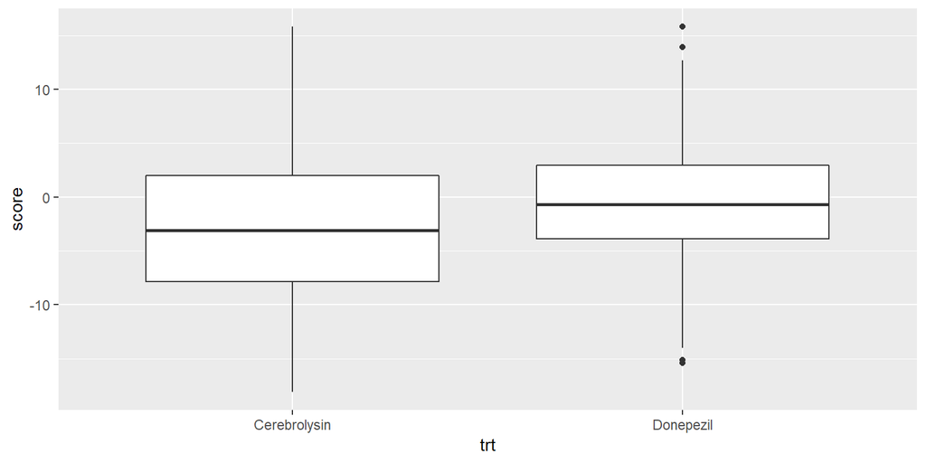

```r
library(ggplot2)
ggplot(data) + geom_boxplot(aes(trt,score))
```

```r
library(equivalence)
tost(y1, y2, 2)
```

```
##
##  Welch Two Sample TOST
##
## data:  y1 and y2
## df = 194.87
## sample estimates:
## mean of x mean of y
##    -2.635    -0.489
##
## Epsilon: 2
## 95 percent two one-sided confidence interval (TOST interval):
##  -3.6547612 -0.6372388
## Null hypothesis of statistical difference is: not rejected
## TOST p-value: 0.5634489
```

```r
tost(y1, y2, 4)
```

```
##
##  Welch Two Sample TOST
##
## data:  y1 and y2
## df = 194.87
## sample estimates:
## mean of x mean of y
##    -2.635    -0.489
##
## Epsilon: 4
## 95 percent two one-sided confidence interval (TOST interval):
##  -3.6547612 -0.6372388
## Null hypothesis of statistical difference is: rejected
## TOST p-value: 0.0218124
```

# 5 Type 2 diabetes

An investigator is exploring whether the expression levels of genes significantly differ between a sample of healthy individuals and a sample of individuals with Type 2 diabetes. He performs a separate t-test comparing the two samples for 5,000 different genes, and uses $\alpha = 0.05$ as his cutoff. His analysis identifes 411 genes as having different expression levels between the two samples.

1. The investigator reasons that because he carried out his t-tests using a type I error rate of 5%, he should expect about 5% of the 411 genes that he discovered to be type I errors. Is this reasoning correct or incorrect? If it is incorrect, what’s wrong with it?
2. What is the investigator’s false discovery rate?

# 6 Identification of genes

Breast cancer is the most common malignant disease in Western women. In these patients, it is not the primary tumour, but its metastases at distant sites that are the main cause of death.

Prognostic markers are needed to identify patients who are at the highest risk for developing metastases, which might enable oncologists to begin tailoring treatment strategies to individual patients. Gene-expression signatures of primary breast tumours might be one way to identify the patients who are most likely to develop metastatic cancer.

The datafile `geneMFS.csv` contains the expression level of 11 genes and the metastasis-free survival (the period until metastasis is detected) for 527 patients.

The objective of this study is to identify which genes may be good or poor prognosis for the development of matastasis.

1. Graphically compare the distribution of the gene expressions in the groups of patients with early metastasis (MFS <1000) and late metastasis (MFS>1000).

```r
data <- read.csv("data/geneMFS.csv")
head(data)
```

```
##   WASF1 WASF2 WASF3 ABI1 ABI2 ABI3 BRK1 NCKAP1 NCKAP1L CYFIP1 CYFIP2
## 1  1.38  0.57  0.26 1.33 0.98 1.13 0.88   1.90    2.89   1.08   3.90
## 2  1.32  0.22  0.05 0.57 0.33 0.82 1.57   0.78    0.87   0.63   1.56
## 3  0.29  0.40  0.14 0.96 0.86 0.73 1.02   0.95    1.08   1.17   1.36
## 4  0.83  0.81  0.42 1.90 0.87 3.57 1.52   1.22    4.57   0.51   3.97
## 5  1.34  0.57  0.62 1.33 0.87 1.99 0.67   1.78    3.27   0.74   1.02
## 6  0.55  0.56  0.72 0.93 0.49 1.18 0.60   1.24    2.06   1.11   1.54
##   survival
## 1    12131
## 2     1189
## 3     8173
## 4    10968
## 5     3978
## 6      628
```

```r
library(reshape2)
dm <- melt(data, id="survival")
head(dm)
```

```
##   survival variable value
## 1    12131    WASF1  1.38
## 2     1189    WASF1  1.32
## 3     8173    WASF1  0.29
## 4    10968    WASF1  0.83
## 5     3978    WASF1  1.34
## 6      628    WASF1  0.55
```

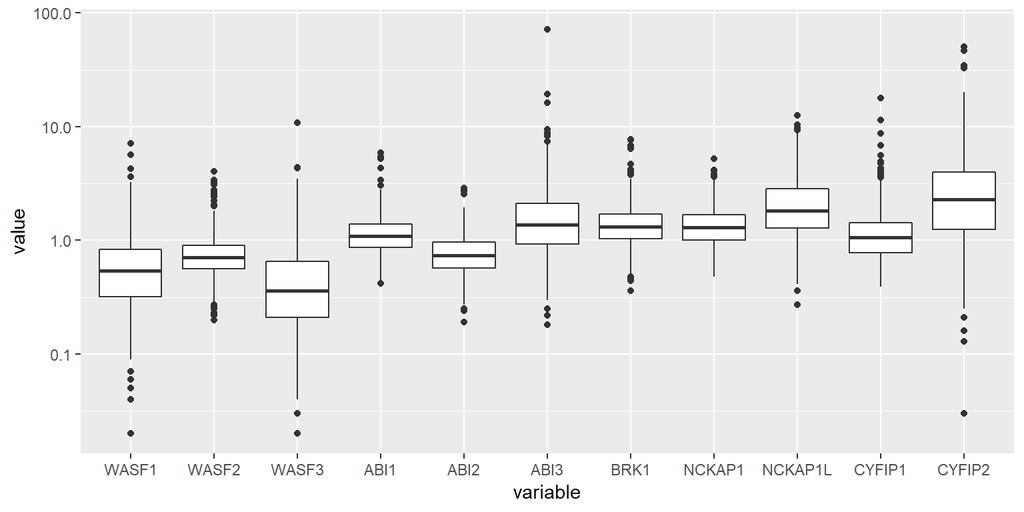

```r
pl <- ggplot(dm) +geom_boxplot(aes(x=variable, y=value))
pl + scale_y_log10()
```

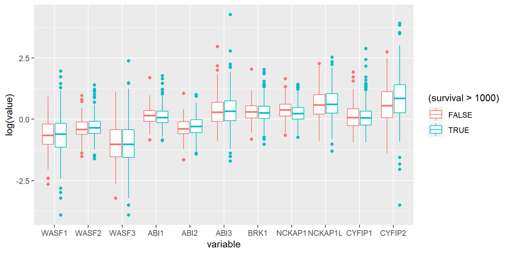

```r
ggplot(dm) +geom_boxplot(aes(x=variable, y=log(value), color=(survival>1000)))
```

2. Compare the gene expression levels in these two groups using a parametric test.

```r
surv.1000 <- data$survival > 1000
j <- 1
dj <- data[,j]
t.test(dj ~ surv.1000)
```

```
##
##  Welch Two Sample t-test
##
## data:  dj by surv.1000
## t = -0.007957, df = 196.17, p-value = 0.9937
## alternative hypothesis: true difference in means is not equal to 0
## 95 percent confidence interval:
##  -0.1264990  0.1254823
## sample estimates:
## mean in group FALSE  mean in group TRUE
##           0.7120388           0.7125472
```

```r
p <- vector(length=11)
for (j in (1:11)) {
  dj <- log(data[,j])
  p[j] <- t.test(dj ~ surv.1000)$p.value
}
print(sort(p))
```

```
##  [1] 0.002432574 0.006863315 0.199144542 0.209007575 0.291273299
##  [6] 0.332027115 0.453659762 0.553232163 0.615709600 0.748519078
## [11] 0.846580769
```

```r
p.adjust(sort(p), method="bonferroni")
```

```
##  [1] 0.02675831 0.07549646 1.00000000 1.00000000 1.00000000 1.00000000
##  [7] 1.00000000 1.00000000 1.00000000 1.00000000 1.00000000
```

```r
p.adjust(sort(p), method="BH")
```

```
##  [1] 0.02675831 0.03774823 0.57477083 0.57477083 0.60871638 0.60871638
##  [7] 0.71289391 0.75253396 0.75253396 0.82337099 0.84658077
```

```r
p <- vector(length=11)
for (j in (1:11)) {
  dj <- data[,j]
  p[j] <- wilcox.test(dj ~ surv.1000)$p.value
}
print(sort(p))
```

```
##  [1] 0.003295722 0.003705678 0.133728589 0.169338169 0.330236536
##  [6] 0.433579267 0.437397955 0.469324557 0.528579877 0.719664187
## [11] 0.930148723
```

```r
p.adjust(sort(p), method="bonferroni")
```

```
##  [1] 0.03625294 0.04076246 1.00000000 1.00000000 1.00000000 1.00000000
##  [7] 1.00000000 1.00000000 1.00000000 1.00000000 1.00000000
```

```r
p.adjust(sort(p), method="BH")
```

```
##  [1] 0.02038123 0.02038123 0.46567997 0.46567997 0.64532127 0.64532127
##  [7] 0.64532127 0.64532127 0.64604207 0.79163061 0.93014872
```